# Notebook

### Web Information Retrieval and Data Mining - Assignment 3

```
Student: Antonissen, Luc (0908502)
```

#### Answer 1.1, Baseline (4p)

- Dense network, at least 3 layers, shaped like a pyramid
  - Last layer: 10 nodes, sigmoid.
  - Loss: categorical cross-entropy. Metric: accuracy
- No preprocessing, regularization. Get at least 70% accuracy.
- Explain design decisions. Discuss performance.
  - Does it overfit (large/growing gap between loss and val_loss)?

[output not shown]

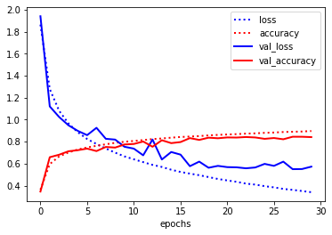

```
Model: "sequential"
_________________________________________________________________
Layer (type)                 Output Shape              Param #
=================================================================
reshape (Reshape)            (None, 3072)              0
_________________________________________________________________
dense (Dense)                (None, 3413)              10488149
_________________________________________________________________
leaky_re_lu (LeakyReLU)      (None, 3413)              0
_________________________________________________________________
dense_1 (Dense)              (None, 1706)              5824284
_________________________________________________________________
leaky_re_lu_1 (LeakyReLU)    (None, 1706)              0
_________________________________________________________________
dense_2 (Dense)              (None, 853)               1456071
_________________________________________________________________
leaky_re_lu_2 (LeakyReLU)    (None, 853)               0
_________________________________________________________________
dense_3 (Dense)              (None, 10)                8540
=================================================================
Total params: 17,777,044
Trainable params: 17,777,044
Non-trainable params: 0
_________________________________________________________________
None
def build_model_1_1():
    model = models.Sequential()
    model.add(layers.Reshape((32**2*3,), input_shape=(32,32,3)))
    model.add(layers.Dense(2**12//1.2))
    model.add(layers.LeakyReLU(.01))
    model.add(layers.Dense(2**11//1.2))
    model.add(layers.LeakyReLU(.01))
    model.add(layers.Dense(2**10//1.2))
    model.add(layers.LeakyReLU(.01))
    model.add(layers.Dense(10, activation='softmax'))
    model.compile(optimizer='sgd',
                  loss='categorical_crossentropy',
                  metrics=['accuracy'])
    return model
```

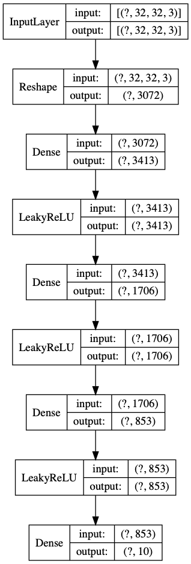

#### Answer 1.2, Preprocess (2p)

- Convert images to greyscale, other preprocessing optional.
  - Input shape should be (32,32,1)
- Explain design decisions. Is it better? Why (not)?
  - Color information is likely not so useful for classification. Greyscale makes the network smaller, less parameters to learn, less likely to overfit.

[output not shown]

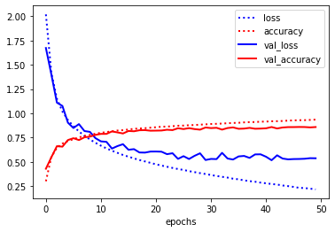

```
Model: "sequential_4"
_________________________________________________________________
Layer (type)                 Output Shape              Param #
=================================================================
reshape_4 (Reshape)          (None, 1024)              0
_________________________________________________________________
dense_16 (Dense)             (None, 3413)              3498325
_________________________________________________________________
leaky_re_lu_12 (LeakyReLU)   (None, 3413)              0
_________________________________________________________________
dense_17 (Dense)             (None, 1706)              5824284
_________________________________________________________________
leaky_re_lu_13 (LeakyReLU)   (None, 1706)              0
_________________________________________________________________
dense_18 (Dense)             (None, 853)               1456071
_________________________________________________________________
leaky_re_lu_14 (LeakyReLU)   (None, 853)               0
_________________________________________________________________
dense_19 (Dense)             (None, 10)                8540
=================================================================
Total params: 10,787,220
Trainable params: 10,787,220
Non-trainable params: 0
_________________________________________________________________
None
def build_model_1_2():
    model = models.Sequential()
    model.add(layers.Reshape((32**2*1,), input_shape=(32,32,1)))
    model.add(layers.Dense(2**12//1.2))
    model.add(layers.LeakyReLU(.01))
    model.add(layers.Dense(2**11//1.2))
    model.add(layers.LeakyReLU(.01))
    model.add(layers.Dense(2**10//1.2))
    model.add(layers.LeakyReLU(.01))
    model.add(layers.Dense(10, activation='softmax'))
    model.compile(optimizer='sgd',
                  loss='categorical_crossentropy',
                  metrics=['accuracy'])
    return model
```

#### Answer 1.3, Tune (4p)

- Regularize the model. What works best?
  - Should consider batch normalization, dropout, l1/l2 regularization (or Nesterov)
- Tune other hyperparameters (e.g. learning rate, batch size,...) as you see fit.
  - At least consider tuning learning rate, ideally also momentum, decay, other optimizers
- Explain your findings and final design decisions. Discuss the results.
  - Should be better, at least it shouldn't overfit

```
SGD still performed best with adam as a close second. I've change sgd to use nesterov momentum and learning rate decay starting with 0.02. The batch size is increased, but makes training slower so more epochs were needed. (length: 222)

Max val score: 88.05%
```

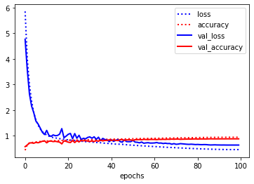

```
def build_model_1_3():
    model = models.Sequential()
    model.add(layers.Reshape((32**2*1,), input_shape=(32,32,1)))
    model.add(layers.Dense(2**12//1.2, kernel_regularizer=regularizers.l2(.001)))
    model.add(layers.LeakyReLU(.01))
    model.add(layers.Dense(2**11//1.2, kernel_regularizer=regularizers.l2(.001)))
    model.add(layers.LeakyReLU(.01))
    model.add(layers.Dense(2**10//1.2, kernel_regularizer=regularizers.l2(.001)))
    model.add(layers.LeakyReLU(.01))
    model.add(layers.Dense(10, activation='softmax'))
    model.compile(optimizer=optimizers.SGD(learning_rate=optimizers.schedules.PolynomialDecay(initial_learning_rate=.02,
                                                                                              decay_steps=95*497,
                                                                                              end_learning_rate=.0001,
                                                                                              power=1.5),
                                           momentum=.9,
                                           nesterov=True),
                  loss='categorical_crossentropy',
                  metrics=['accuracy'])
    return model
```

#### Answer 2.1, ConvNet (7p)

- Build a sequential ConvNet, get at least 90% accuracy.
  - Conv2D layers, input shape (32,32,1)
  - Consider using blocks of Conv2D layers with maxpooling in between
  - Use zero-padding in Conv2D layers because the images are small
  - At least one dense hidden layer and dense output layer (sigmoid)
  - Consider adding batch normalization, dropout
  - Consider small dropout rates in beginning, larger dropout rates later in network
  - Consider other optimizers and tuning learning rate, momentum,...
- Explain what you did and why (800 chars). Is it working well?
  - Should be quite elaborate and sensible

[output not shown]

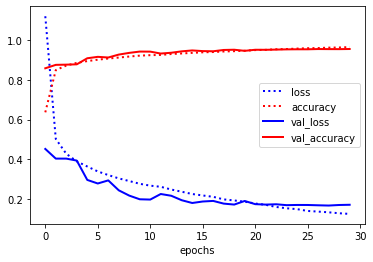

```
Model: "sequential_3"
_________________________________________________________________
Layer (type)                 Output Shape              Param #
=================================================================
conv2d_21 (Conv2D)           (None, 29, 29, 32)        544
_________________________________________________________________
batch_normalization_27 (Batc (None, 29, 29, 32)        128
_________________________________________________________________
leaky_re_lu_27 (LeakyReLU)   (None, 29, 29, 32)        0
_________________________________________________________________
dropout_21 (Dropout)         (None, 29, 29, 32)        0
_________________________________________________________________
conv2d_22 (Conv2D)           (None, 29, 29, 64)        18496
_________________________________________________________________
batch_normalization_28 (Batc (None, 29, 29, 64)        256
_________________________________________________________________
leaky_re_lu_28 (LeakyReLU)   (None, 29, 29, 64)        0
_________________________________________________________________
conv2d_23 (Conv2D)           (None, 29, 29, 64)        36928
_________________________________________________________________
batch_normalization_29 (Batc (None, 29, 29, 64)        256
_________________________________________________________________
leaky_re_lu_29 (LeakyReLU)   (None, 29, 29, 64)        0
_________________________________________________________________
max_pooling2d_9 (MaxPooling2 (None, 14, 14, 64)        0
_________________________________________________________________
dropout_22 (Dropout)         (None, 14, 14, 64)        0
_________________________________________________________________
conv2d_24 (Conv2D)           (None, 14, 14, 64)        36928
_________________________________________________________________
batch_normalization_30 (Batc (None, 14, 14, 64)        256
_________________________________________________________________
leaky_re_lu_30 (LeakyReLU)   (None, 14, 14, 64)        0
_________________________________________________________________
conv2d_25 (Conv2D)           (None, 14, 14, 64)        36928
_________________________________________________________________
batch_normalization_31 (Batc (None, 14, 14, 64)        256
_________________________________________________________________
leaky_re_lu_31 (LeakyReLU)   (None, 14, 14, 64)        0
_________________________________________________________________
```

[output cut: 56 more lines]

```
    model.add(layers.BatchNormalization())
    model.add(layers.LeakyReLU(.01))
    model.add(layers.Dropout(0.5))
    model.add(layers.Dense(2**7, kernel_constraint=constraints.MaxNorm(2)))
    model.add(layers.BatchNormalization())
    model.add(layers.LeakyReLU(.01))
    model.add(layers.Dropout(0.5))
    model.add(layers.Dense(10, kernel_constraint=constraints.MaxNorm(2), activation='softmax'))
    model.compile(optimizer=optimizers.Adam(learning_rate=optimizers.schedules.PolynomialDecay(initial_learning_rate=.002,
                                                                                               decay_steps=30*993,
                                                                                               end_learning_rate=.0001,
                                                                                               power=1.5)),
                  loss='categorical_crossentropy',
                  metrics=['accuracy'])
    return model
```

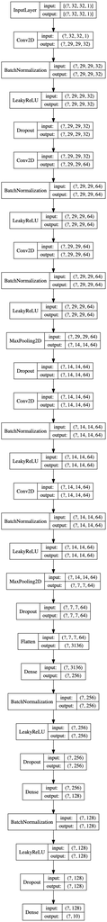

#### Answer 2.2, Data Augmentation (3p)

- Augment the preprocessed training data.
  - Use small variations (small shifts up-down, left-right) of flips becasue the images are small
  - Large shifts and rotations distort the image too much
- Explain what you did and why. Discuss the performance of the model.

```
Only width_shift_range and height_shift_range with a very small range (.05) gave improved results. The final model performs a tiny bit better than the model without data augmentation, 95,9% and 95,6% respecively. (length: 213)

Max val score: 95.94%
```

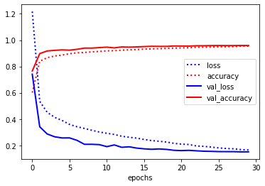

```
train_data_gen = ImageDataGenerator(
    width_shift_range=.05,
    height_shift_range=.05
)
```

#### Answer 3.1, Misclassifications (2p)

[output not shown]

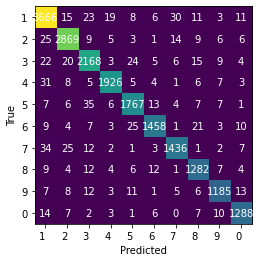

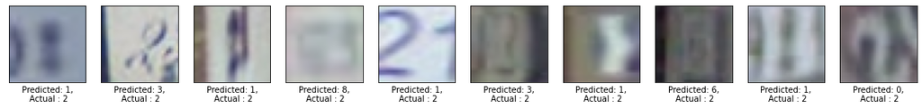

#### Answer 3.2, Activations (4p)

- Retrieve and visualize the activations for one example
- For every filter for different convolutional layers (at different depths in the network).
- Give an explanation. Is your model indeed learning something useful?
  - Should detect edges etc in first layers, higher-order object (e.g. interesting regions) in deeper layers.

[output not shown]

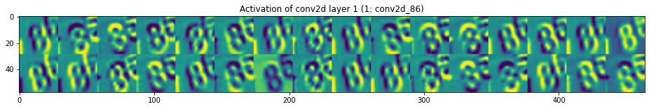

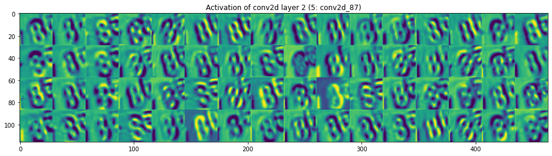

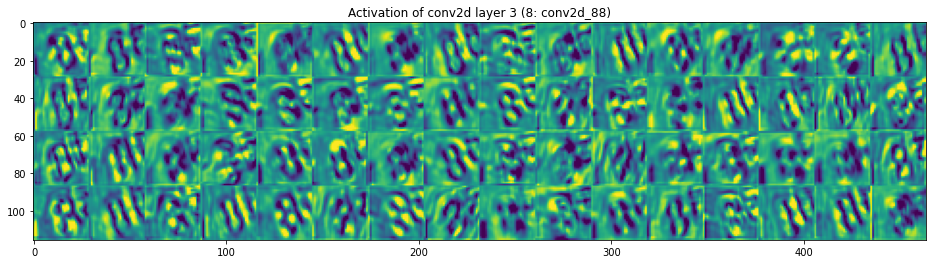

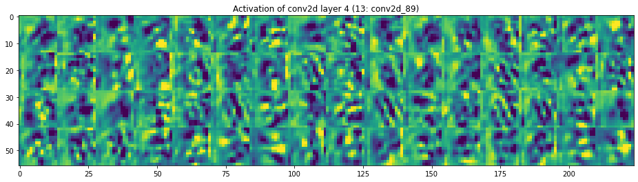

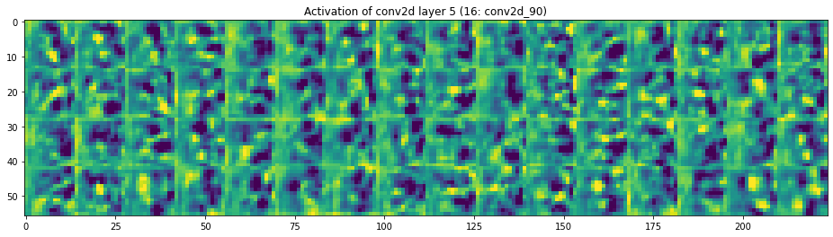

#### Answer 3.3, Class activation map (4p)

- Show a class activation map for your last convolutional layer
- Superimpose the activation map over the image, or plot side by side
  - Should make sense, detect interesting regions to classify the number

[figure not shown]

```
def plot_activation_map():
    images_per_row = 16
    heatmap_intensity = .25

    backend.clear_session()
    tf.compat.v1.disable_eager_execution()

    model = load_model_from_file(base_dir, "model_2_2")
    X_example = rgb2gray(np.expand_dims(X_test[0], axis=0))[0]
    y_example = y_test[0]

    def get_last_conv2d_layer():
        for layer in model.layers[::-1]:
            if 'conv2d_' in layer.name:
                return layer


    last_conv2d_layer = get_last_conv2d_layer()
    grads = backend.gradients(model.output, last_conv2d_layer.output)[0]
    pooled_grads = backend.mean(grads, axis=(0, 1, 2))
    iterate = backend.function([model.input], [pooled_grads, last_conv2d_layer.output[0]])
    pooled_grads_value, conv_layer_output_value = iterate([np.expand_dims(X_example, axis=0)])

    for i in range(64):
        conv_layer_output_value[:, :, i] *= pooled_grads_value[i]

    heatmap = np.mean(conv_layer_output_value, axis=-1)
    heatmap = np.maximum(heatmap, 0)
    heatmap /= np.max(heatmap)

    img = np.concatenate((X_example, X_example, X_example), axis=2) * 255
    heatmap = cv2.resize(heatmap, (img.shape[1], img.shape[0]))
    heatmap = np.uint8(255 * heatmap)
    heatmap = cv2.applyColorMap(heatmap, cv2.COLORMAP_JET)

    superimposed_img = heatmap * heatmap_intensity + img * (1 - heatmap_intensity)

    fig, (ax1, ax2, ax3) = plt.subplots(1, 3, figsize=(16, 5))
    fig.suptitle('Visualization example of the last conv2d layer', fontsize=16)
    ax1.imshow(X_example[:, :, 0], cmap='gray')
    ax2.matshow(heatmap)
    ax3.imshow(superimposed_img.astype(np.uint8), vmin=0, vmax=255)
    plt.show()
```

#### Answer 4.1, Fast feature extraction (5p)

- Import the VGG16 model, pretrained on ImageNet
- Freeze convolutional base, adds a dense layer
- Consider unfreezing the last few convolutional layers and evaluate whether that works better
  - Check if they do. It is very likely to help.
- Discuss the observed performance
  - Should get around 80% accuracy

[output not shown]

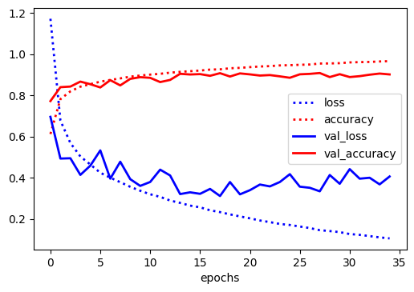

```
Model: "sequential_9"
_________________________________________________________________
Layer (type)                 Output Shape              Param #
=================================================================
vgg16 (Model)                (None, 1, 1, 512)         14714688
_________________________________________________________________
flatten_6 (Flatten)          (None, 512)               0
_________________________________________________________________
dropout_18 (Dropout)         (None, 512)               0
_________________________________________________________________
dense_27 (Dense)             (None, 2048)              1050624
_________________________________________________________________
batch_normalization_19 (Batc (None, 2048)              8192
_________________________________________________________________
leaky_re_lu_28 (LeakyReLU)   (None, 2048)              0
_________________________________________________________________
dropout_19 (Dropout)         (None, 2048)              0
_________________________________________________________________
dense_28 (Dense)             (None, 10)                20490
=================================================================
Total params: 15,793,994
Trainable params: 12,874,250
Non-trainable params: 2,919,744
_________________________________________________________________
None
def build_model_4_1():
    conv_base = applications.vgg16.VGG16(weights='imagenet',
                                         include_top=False,
                                         input_shape=(32, 32, 3))

    model = models.Sequential()
    model.add(conv_base)

    model.add(layers.Flatten())
    model.add(layers.Dropout(0.5))
    model.add(layers.Dense(2**11, kernel_constraint=constraints.MaxNorm(2)))
    model.add(layers.BatchNormalization())
    model.add(layers.LeakyReLU(.01))
    model.add(layers.Dropout(0.5))
    model.add(layers.Dense(10, kernel_constraint=constraints.MaxNorm(2), activation='softmax'))

    conv_base.trainable = True
    set_trainable = False
    for layer in conv_base.layers:
        if layer.name == 'block4_conv2':
            set_trainable = True
        layer.trainable = set_trainable

    model.compile(optimizer=optimizers.SGD(),
              loss='categorical_crossentropy',
              metrics=['accuracy'])

    return model
```

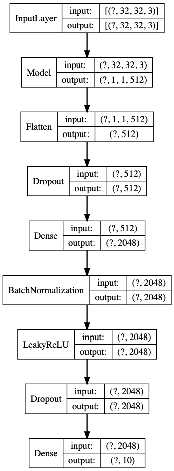

#### Answer 4.2, Embeddings (5p)

- Generate embeddings with the trained convolutional part of model_4_1 (without the dense layer)
- Embed the training and test data and store them to disk
- Build and evaluate a pipeline on the embedded data
  - Check if pipeline makes sense (e.g. use models that can handle many dimensions)
- Describe what you did and what you observed (max 800 chars).
  - Consider different models, preprocessing, tuning, etc.
  - Check performance (see original Submission.html) when in doubt. We did not run all the evaluations because it takes too long, and the output is ill-defined.

[output not shown]

```
Running time: 75.03 seconds
Last modified: May 26, 2020
scikit-learn version: 0.23.1
```